# Project 1 Data Story on Song Lyrics

Runzi Qiang

> *Telling the story of The Times with Lyrics*

[figure not shown]

## 1. The Theme of the Times

According to the lyrics data collecting from 1970 to 2016, I divided the dataset into the 19th and 20th centuries lyrics, in order to do a evaluation of the most frequently used words in the 2 different set of lyrics.

First, I visualize the word cloud of top 200 used words of the whole dataset.

[interactive chart not shown]

Then, I draw most frequently used words in lyrics histogram in 19th century to make comparison with 20th century.

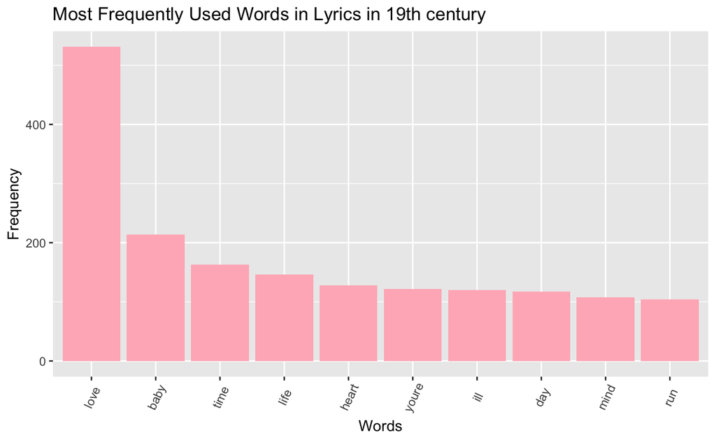

**Love, Baby, Time**, these three words are the words that people mostly like to write in the lyrics in the last century. In addition, the theme of the lyrics is related to meaningful and positive themes: **life, heart, day, mind, run** and **ill** is the only negative word in top10 keywords. If the lyrics can reflect the condition and mood of life, I think people in the last century will enjoy life and feel relaxed.

Let’s see what happens to the theme words of the 20th century.

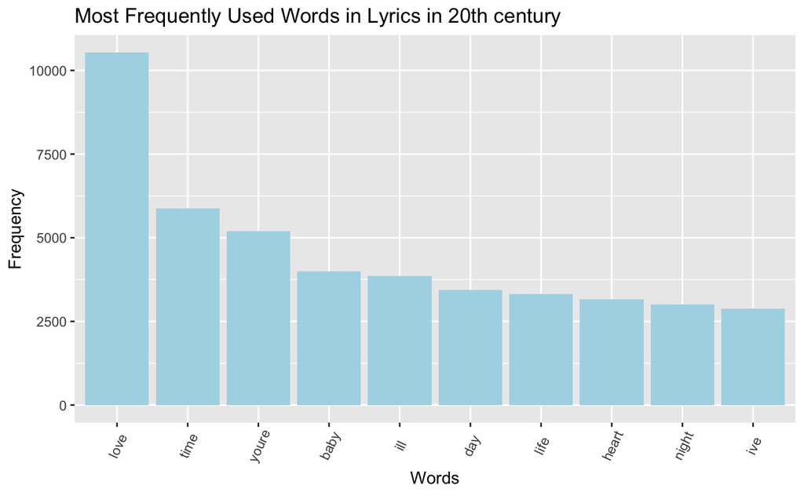

## 2. Interesting finding according to lyrics during times

### 2.1 The most prolific years

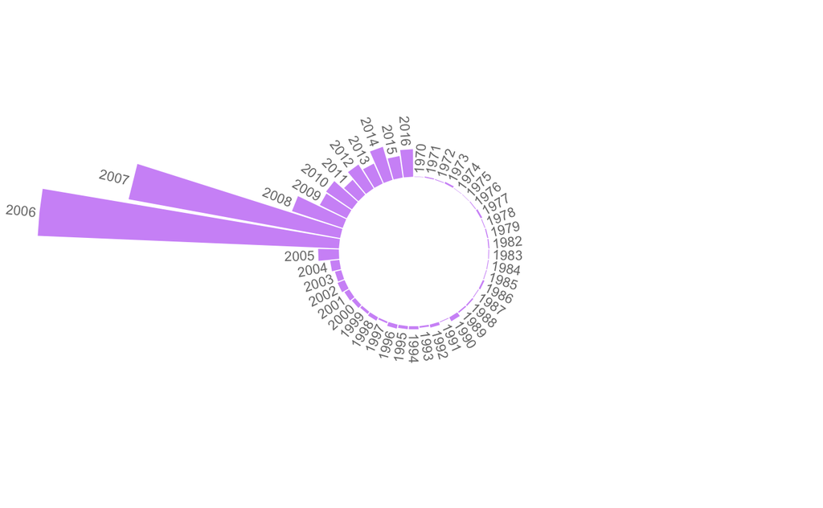

From the graph I found that the most prolific years is 2006 and 2007, which is over many times than other years, this is marks the beginning of the era of pop music. I’ll give more specific data to show the count of songs per year.

Songs Counts Per Year

| year | song_count | id |
| --- | --- | --- |
| 2006 | 886 | 35 |
| 2007 | 632 | 36 |
| 2008 | 157 | 37 |
| 2014 | 101 | 43 |
| 2010 | 92 | 39 |

### 2.2 The most longest lyrics

According to the previous analysis, the proportion of some modal verbs such like **“youre, ive”** in the lyrics is slightly increasing, which may reflect that modern literati prefer to write daily lyrics.  
For further verification, I divided the data set into five data sets by decades and statistic the length of the lyrics for five decades from 1970s to 2010s.

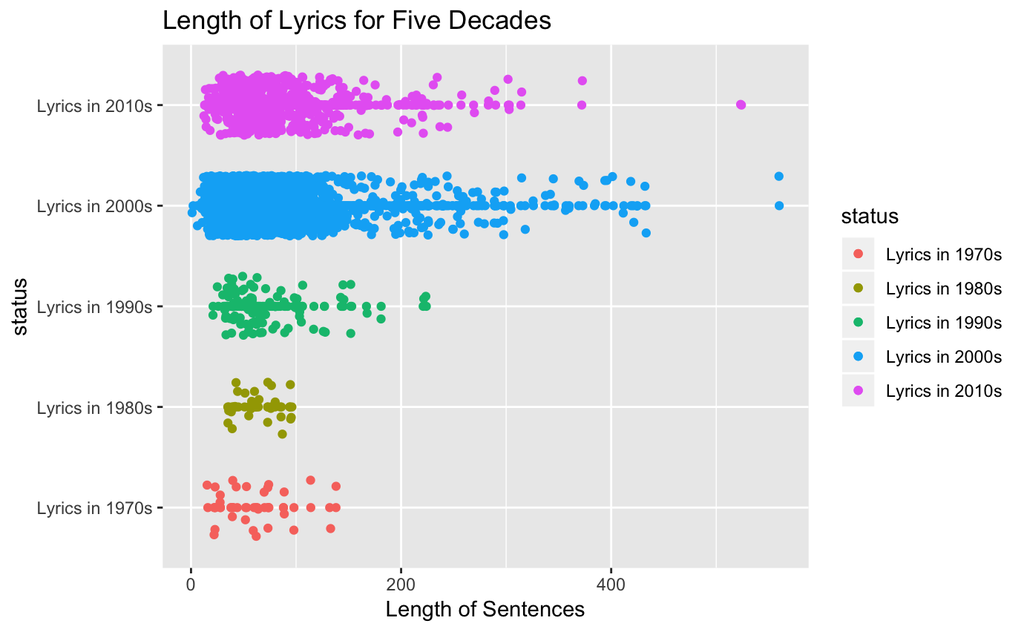

Although the datasets of each age are unevenly distributed, I can still get some conclusions. The length of the lyrics is getting longer as the times go by, there are essential changes from the 19th century to the 20th century. The previous lyrics are more written, concise, refined and now lyrics are more routine and daily.

### 2.3 Lexical Diversity and Density

The more varied a vocabulary a text possesses, the higher its lexical diversity. Song Vocabulary is a representation of how many unique words are used in a song.  
And lexical density is defined as the number of unique words divided by the total number of words. This is an indicator of word repetition, which is a critical songwriter’s tool. As lexical density increases, repetition decreases.  
I plot the two graphs together in order to compare it to diversity and density.

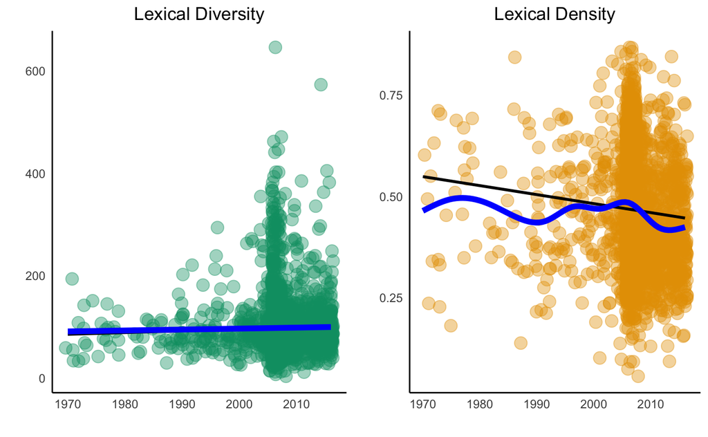

## 3. Sentiment Analysis

I will measure the sentiments of song lyrics in 5 different decades to make comparison. Bing lexicon assigns words to positive and negative categories. AFINN lexicon assign each word with a score from -5 to 5 where higher score means more positive sentiment.

I will use the Bing lexicon as an example.

| Lyrics_Groups | bing |
| --- | --- |
| Lyrics in 1970s | 0.7836257 |
| Lyrics in 1980s | 0.6578947 |
| Lyrics in 1990s | 0.8354633 |
| Lyrics in 2000s | 0.5675039 |
| Lyrics in 2010s | 0.6259713 |

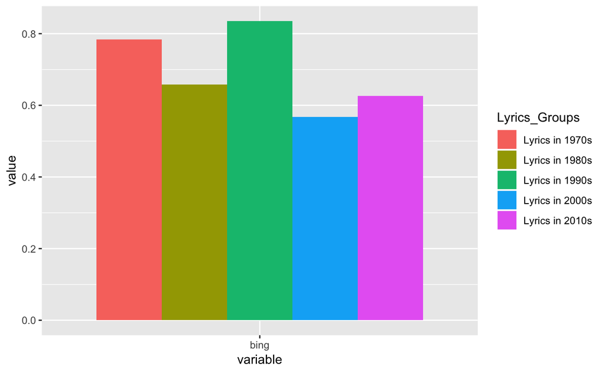

The sentiment score of bing lexicon is the amount of positive words divided by negative words. The results show that lyrics in 1990s have a significantly higher score than lyrics in 2000s and 19th century’s lyrics are more positive than 20th century obviously which verifies my previous inferences that people’s life become more stressful and struggle.

## 4. Topic Modeling

I will extract topics with fitting a LDA model. We tried setting the numbers of topics as three to six. It turns out that setting three topics number make the most sense. The beta matrix tells us the probabilities of each word being generated from each topic.

| topic | term | beta |
| --- | --- | --- |
| 1 | admire | 1.570543e-04 |
| 2 | admire | 2.538727e-05 |
| 3 | admire | 1.861844e-06 |
| 1 | america | 7.230157e-04 |
| 2 | america | 2.513591e-07 |
| 3 | america | 2.066647e-04 |
| 1 | answer | 2.843956e-04 |
| 2 | answer | 6.914889e-04 |
| 3 | answer | 1.861844e-06 |

The word “admire”" is generated from the topic 1 with a probability of 1.570543e-04, and the word “america” takes account 7.230157e-04.  
Then I visualized the top ten most frequent words in each topics.

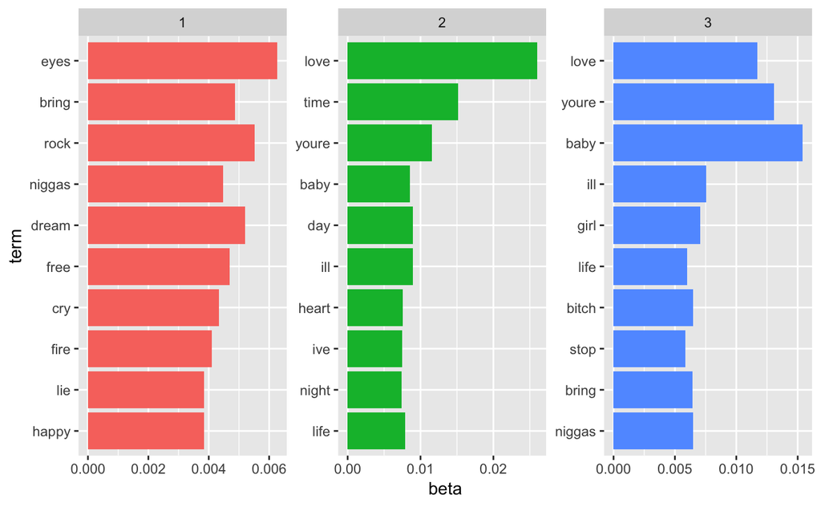

The top ten words has become more different than theme topic, there are many new words such as “eyes”,“free”,“gril” related to each topic.

## 5. Conclusion

Lyrics can bring us a lot of thinking through data analysis, text mining and statistics.

The lyrics can reflect the changes and progress of the times, the happiness and the pressure of people’s lives. More deeply, the lyrics can reflect the economic state of society and even the country, people’s material life and cultural preferences.

**But no matter how the times change, the most important theme in the lyrics is always love.**

[figure not shown]

love